# Predicción ventas Apple

Daniel Corral Ruiz

16-11-2020

## Introducción

El objetivo es predecir las ventas de Apple. Para ello, hemos acudido a Bloomberg y hemos obtenido los datos trimestrales desde el 2T de 2008 hasta el 3T del 2017. En primer lugar vamos a proceder importar los datos.

```r
Apple <- read.csv("IngresosApple.csv", sep=";", dec=",")
View(Apple)
```

## Modificamos el dataset

A través de los resultados obtenidos en la tabla, podemos añadir un breve análisis exploratorio de datos. Tenemos que cambiar el formato del periodo, para ello creamos un nuevo valor con los datos de los trimestres formateados a fecha. Una vez que hemos creado las fechas correctas, añadimos una nueva variable con estos datos, mediante mutate del paquete “dplyr”.

```r
Apple[is.na(Apple)] <- 0
fechas <- seq(as.Date("2008-04-01"), as.Date("2017-09-30"), by = "quarter")
Apple <- mutate(Apple, Date = fechas)
xVentas=xts(Apple$Ingresos, order.by = as.Date(Apple$Date),frequency=4)
xVentas = to.quarterly(xVentas)
zVentas = as.zoo(xVentas$xVentas.Close)
View(zVentas)
```

## Representación gráfica

Podemos observar gráficamente las ventas de Apple en trimestres, para una mejor interpretación de nuestros datos.

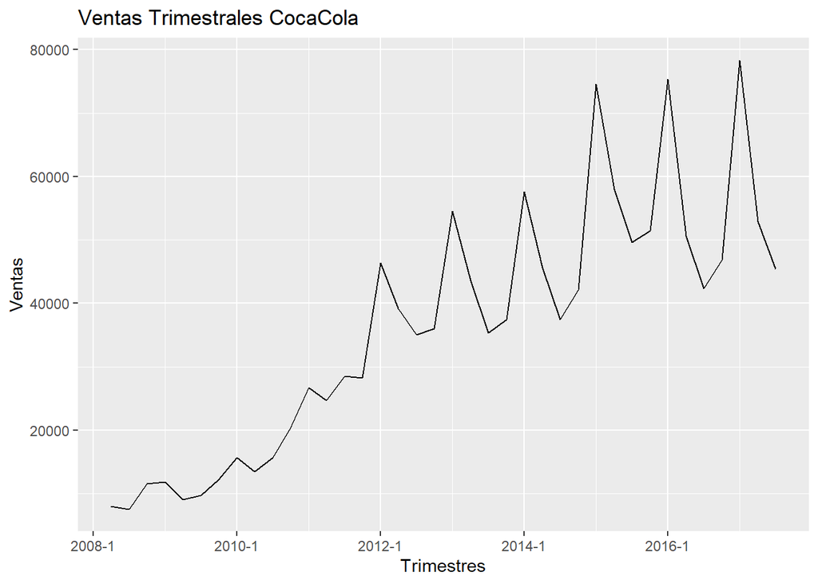

```r
autoplot(zVentas)+ylab("Ventas")+ggtitle("Ventas Trimestrales CocaCola")+xlab("Trimestres")
```

Podemos observar una tendencia creciente y una estacionaridad en sus ventas. A su vez, podemos dividir el gráfico por trimestres.

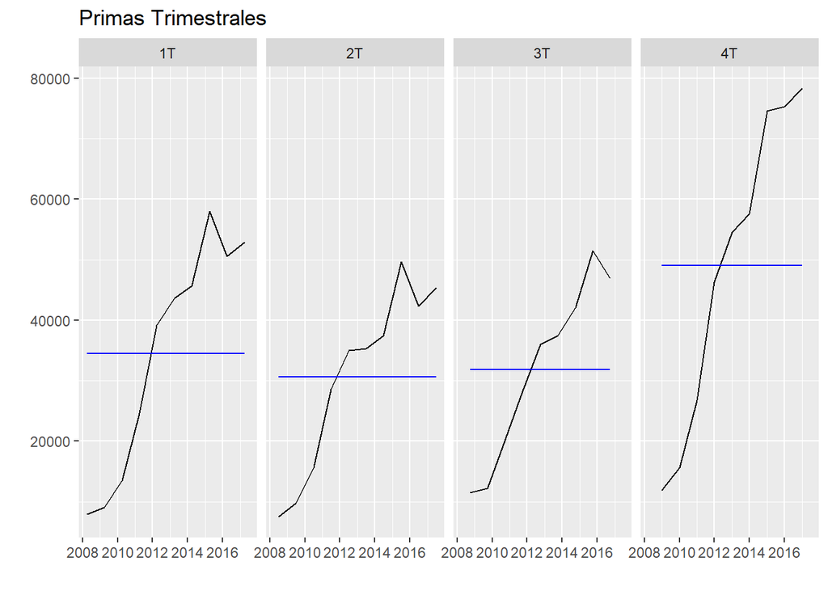

```r
tsVentas=ts(coredata(zVentas), start = c(2008, 2), frequency = 4)
#Seasonal Plot
ggfreqplot(tsVentas,freq=4,nrow=1,facet.labeller=c("1T","2T","3T","4T"))+ggtitle("Primas Trimestrales")
```

Podemos hacer una gráfica con los componentes que tienen: Observamos su estacionaridad.

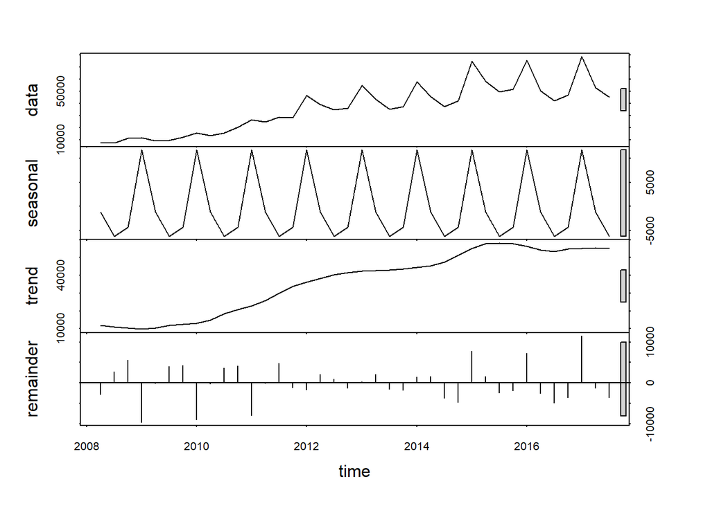

```r
plot(stl(tsVentas[, 1], s.window = "periodic"))
```

## Modelo ETS

Suavizamiento exponencial (ETS) es un algoritmo estadístico local de uso común para la predicción de series temporales. El algoritmo ETS es especialmente útil para conjuntos de datos con estacionalidad y otras suposiciones previas sobre los datos. ETS calcula un promedio ponderado sobre todas las observaciones en el conjunto de datos de las series temporales de entrada como su predicción. Las ponderaciones disminuyen exponencialmente con el tiempo, en lugar de las ponderaciones constantes en los métodos de promedio móvil simple. Las ponderaciones dependen de un parámetro constante, conocido como parámetro de suavizamiento.

Tenemos que dejar fuera de la estimación los trimestres de 2017 (3 en nuestro dataset). Mediante la funcion ets(), escogemos el mejor modelo posible.

```r
cOmit=3
nObs=length(zVentas)
oVentas <- window(zVentas,start=index(zVentas[1]),end=index(zVentas[nObs-cOmit]))
ets(oVentas)
```

```
## ETS(M,A,M)
##
## Call:
##  ets(y = oVentas)
##
##   Smoothing parameters:
##     alpha = 0.493
##     beta  = 0.493
##     gamma = 0.507
##
##   Initial states:
##     l = 7125.3462
##     b = 1485.7975
##     s = 1.1511 1.1163 0.8322 0.9004
##
##   sigma:  0.1222
##
##      AIC     AICc      BIC
## 703.9538 711.1538 717.9519
```

### Predecimos mediante el mejor ETS

Una vez que tenemos el mejor modelo ETS, realizamos la predicción:

```r
## Seleccionamos automaticamente ETS
etsfit<-ets(oVentas)
#forecast model
fventas.ets = forecast(etsfit)
#Resultados
summary(fventas.ets)
```

```
##
## Forecast method: ETS(M,A,M)
##
## Model Information:
## ETS(M,A,M)
##
## Call:
##  ets(y = oVentas)
##
##   Smoothing parameters:
##     alpha = 0.493
##     beta  = 0.493
##     gamma = 0.507
##
##   Initial states:
##     l = 7125.3462
##     b = 1485.7975
##     s = 1.1511 1.1163 0.8322 0.9004
##
##   sigma:  0.1222
##
##      AIC     AICc      BIC
## 703.9538 711.1538 717.9519
##
## Error measures:
##                   ME     RMSE      MAE       MPE     MAPE      MASE      ACF1
## Training set -41.934 4120.155 2883.262 -0.297759 8.677434 0.4160202 0.1438481
##
## Forecasts:
##         Point Forecast     Lo 80     Hi 80      Lo 95     Hi 95
## 2017 Q1       69439.83 58568.387  80311.27  52813.394  86066.26
## 2017 Q2       53347.98 41773.016  64922.95  35645.598  71050.37
## 2017 Q3       48972.04 33884.613  64059.47  25897.811  72046.27
## 2017 Q4       54176.09 31475.035  76877.14  19457.824  88894.35
## 2018 Q1       80540.07 32680.293 128399.85   7344.857 153735.28
## 2018 Q2       61619.03 17211.212 106026.85  -6296.866 129534.93
## 2018 Q3       56344.41  7869.773 104819.05 -17791.151 130479.97
## 2018 Q4       62103.80  -718.363 124925.97 -33974.410 158182.02
```

Y representamos gráficamente la predicción:

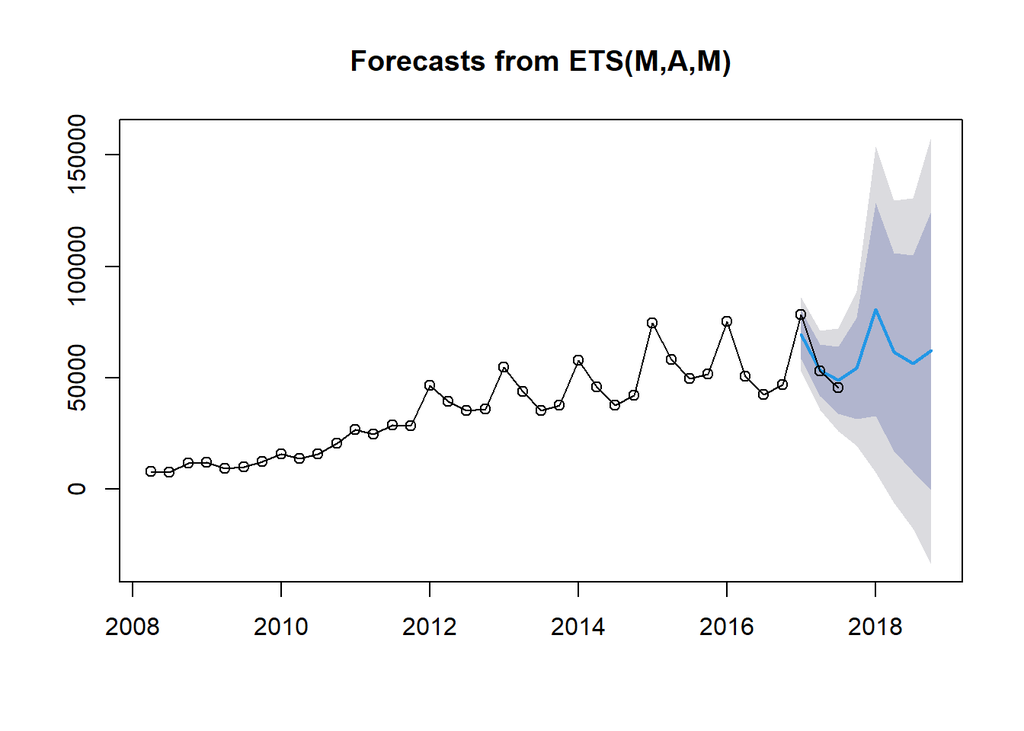

```r
plot(fventas.ets)
lines(window(zVentas),type="o")
```

```r
matrix(c(fventas.ets$mean[1:cOmit],zVentas[(nObs-cOmit+1):nObs]),ncol=2)
```

```
##          [,1]  [,2]
## [1,] 69439.83 78351
## [2,] 53347.98 52896
## [3,] 48972.04 45408
```

Podemos crear una matriz con la comparación entre los resultados reales y nuestra predicción, para así comparar la veracidad de la predicción.

### Precisión de predicción

Podemos ver las salidas de nuestra predicción, con el fin de ver los errores de esta:

```r
etsfit<-ets(window(tsVentas,end=2016+4/4))
fventas.ets=forecast(etsfit,h=cOmit)
forecast:::testaccuracy(fventas.ets$mean,window(tsVentas,start=2017),test = NULL, d = NULL, D = NULL)
```

```
##           ME         RMSE          MAE          MPE         MAPE         ACF1
## -9937.360471 10259.914274  9937.360471   -20.733460    20.733460    -0.500000
##    Theil's U
##     1.667969
```

## Modelo ARIMA

El modelo Arima es una metodología econométrica basada en modelos dinámicos que utiliza datos de series temporales. Para trabajar con modelos ARIMA es necesario tener en cuenta una serie de conceptos básicos tales como: proceso estocástico, ruido blanco, sendero aleatorio y estacionariedad.

Un proceso estocástico es una sucesión de variables aleatorias ({Yt}, t = -∞,…-1, 0, 1,…, ∞) que dependen de un parámetro, en el caso de las series temporales este parámetro es el tiempo.

Un ruido blanco es una sucesión de variables aleatorias que se caracterizan por tener una esperanza constante e igual a cero, igual varianza, y además, son independientes a lo largo del tiempo (covarianza es cero).

Un sendero aleatorio es un proceso estocástico que se caracteriza porque su primera diferencia es un ruido blanco.

Un proceso estocástico es débilmente estacionario o estacionario en un sentido amplio, si se cumple que su media y su varianza son constantes para cualquier período de tiempo y las covarianzas entre dos variables solo dependen del lapso de tiempo que transcurre entre ellas.

```r
fit1=auto.arima(oVentas,lambda=0)
summary(fit1)
```

```
## Series: oVentas
## ARIMA(0,1,0)(0,1,0)[4]
## Box Cox transformation: lambda= 0
##
## sigma^2 estimated as 0.01472:  log likelihood=20.72
## AIC=-39.45   AICc=-39.3   BIC=-38.04
##
## Training set error measures:
##                     ME     RMSE      MAE       MPE     MAPE      MASE      ACF1
## Training set -764.5058 4786.405 3054.054 -1.321616 8.284962 0.4406634 0.1269135
```

El mejor modelo ARIMA es un: ARIMA(0,1,0)(0,1,0)[4]. Podemos representar un análisis de residuos:

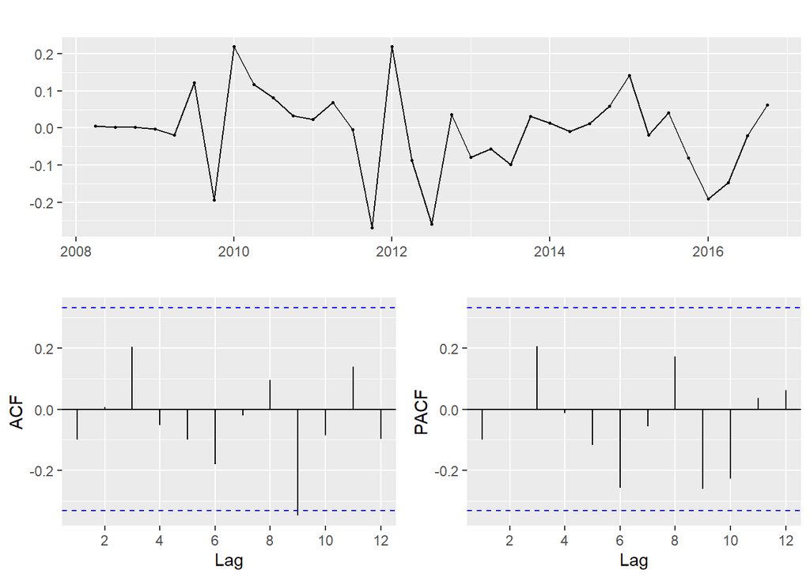

```r
ggtsdisplay(fit1$residuals)
```

### Test Ljung–Box

Para examinar las series de datos en busca de evidencia de cualquier correlación serial usamos la prueba estadística Ljung‐Box. Donde:

- Ho: Hipótesis Nula (ruido blanco)
- H1: Hipótesis alternativa (no ruido blanco)

```r
Box.test(fit1$residuals,lag=4, fitdf=3, type="Lj")
```

```
##
##  Box-Ljung test
##
## data:  fit1$residuals
## X-squared = 2.1794, df = 1, p-value = 0.1399
```

```r
Box.test(fit1$residuals,lag=8, fitdf=3, type="Lj")
```

```
##
##  Box-Ljung test
##
## data:  fit1$residuals
## X-squared = 4.501, df = 5, p-value = 0.4797
```

```r
Box.test(fit1$residuals,lag=12, fitdf=3, type="Lj")
```

```
##
##  Box-Ljung test
##
## data:  fit1$residuals
## X-squared = 12.477, df = 9, p-value = 0.1877
```

Aceptamos hipótesis nula, por lo tanto son ruido blanco.

### Predicción

Hacemos predicción con nuestro modelo ARIMA:

```r
fventas.arima=forecast(fit1)
fventas.arima
```

```
##         Point Forecast    Lo 80    Hi 80    Lo 95     Hi 95
## 2017 Q1       68524.50 58656.57 80052.53 54021.77  86920.63
## 2017 Q2       45993.21 36914.17 57305.26 32857.77  64379.78
## 2017 Q3       38534.34 29436.35 50444.28 25525.07  58174.00
## 2017 Q4       42622.67 31230.74 58169.99 26490.28  68579.55
## 2018 Q1       62338.78 40156.60 96774.23 31816.09 122143.34
## 2018 Q2       41841.40 24416.21 71702.49 18358.80  95360.44
## 2018 Q3       35055.84 18821.04 65294.59 13541.05  90754.54
## 2018 Q4       38775.11 19344.31 77723.59 13387.03 112310.89
```

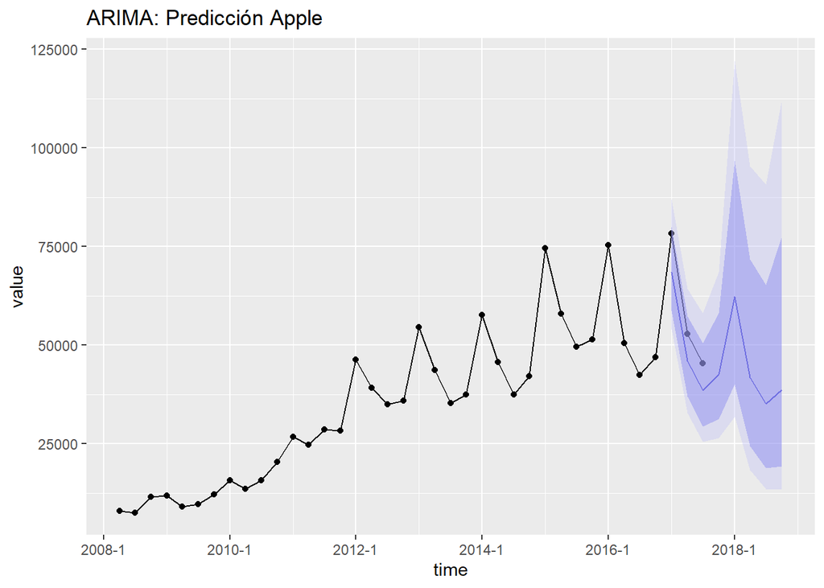

```r
df_new <- data.frame(value = as.vector(zVentas),
                     time = time(zVentas))
ggplot(df_new)+geom_point(aes(x=time,y=value))+geom_line(aes(x=time,y=value))+ geom_forecast(fventas.arima,alpha=0.4)+ggtitle("ARIMA: Predicción Apple")
```

Podemos comparar ambos modelos para compararlos, en nuestro caso tenemos un mejor MAPE en el ARIMA, al ser menor que el modelo ETS.

```r
summary(fit1) # ARIMA
```

```
## Series: oVentas
## ARIMA(0,1,0)(0,1,0)[4]
## Box Cox transformation: lambda= 0
##
## sigma^2 estimated as 0.01472:  log likelihood=20.72
## AIC=-39.45   AICc=-39.3   BIC=-38.04
##
## Training set error measures:
##                     ME     RMSE      MAE       MPE     MAPE      MASE      ACF1
## Training set -764.5058 4786.405 3054.054 -1.321616 8.284962 0.4406634 0.1269135
```

```r
summary(etsfit) #ETS
```

```
## ETS(M,A,M)
##
## Call:
##  ets(y = window(tsVentas, end = 2016 + 4/4))
##
##   Smoothing parameters:
##     alpha = 0.5096
##     beta  = 0.5087
##     gamma = 0.4904
##
##   Initial states:
##     l = 7109.2707
##     b = 1487.6017
##     s = 1.1491 1.1175 0.8354 0.898
##
##   sigma:  0.1223
##
##      AIC     AICc      BIC
## 726.7536 733.6766 741.0052
##
## Training set error measures:
##                    ME     RMSE      MAE        MPE     MAPE      MASE      ACF1
## Training set 204.6779 4252.598 3041.503 0.01734378 8.795167 0.4467153 0.2075367
```